# Exercise Quality Prediction from Accelerometer Data

catharpin

November 8, 2015

# Executive Summary

Using accelerometer and position sensor data collected from test subjects performing physical exercises in a controlled environment, a machine learning algorithm is developed to predict whether these exercises are being done correctly (and, if incorrect, if the incorrect performance can be specifically categorized.)

Using a boosting with trees algorithm, using K-fold cross validation (n=10), a model is developed that with an error rate of 3.93%, with a 95% confidence interval of (3.34%,4.58%). This error estimation was determined by withholding 20% of the training data by random sampling.

# Libraries Used

```r
library(doMC)
library(caret)
registerDoMC(cores=8)
set.seed(10191)
```

# Retrieving Data

The data used is from the “Weight Lifting Exercises Dataset”, retrieved 08 NOV 2015 from http://groupware.les.inf.puc-rio.br/har#dataset [1].

```
## Training data found.
## Testing data found.
```

# Data Cleansing

Many of the variables are entirely missing from the test set and as a result have no predictive value. These are removed from both training and test sets to increase tidiness and reduce effort of the fitting algorithm; we also remove time-of-day and data-collection artifacts.

Initial fitting of the data showed the ‘num_window’ variable (column 7 in the data) as highly influential.  
While it improved the accuracy of the model, in the author’s opinion it is not a valid predictor in the spirit of the effort, as it is an artifact of how the data was collected, and was removed.

```r
# Remove near-zero variables (from the testing set) from data frames.
nzv_test <- nearZeroVar(orig_test)
test <- orig_test[,-nzv_test]
train <- orig_train[,-nzv_test]

# Remove data-collection artifacts from data frames.
test <- test[,c(-1,-3:-6)]
train <- train[,c(-1,-3:-6)]
```

# Data Segmentation

To provide an independent evaluation of the out-of-sample error rate, the training sample is further subdivided into training and ‘self-test’ sets.

```r
inTrain <- createDataPartition(y = train$classe, p=0.8, list=FALSE)
train2<-train[inTrain,]
self_test<-train[-inTrain,]
```

# Model Fit

Some of the data could not be converted to numeric values, causing the fit function to emit a warning; I have chosen to leave those as NA rather than to impute them, as it wasn’t necessary to obtain a high-accuracy fit.

```r
tc <- trainControl(method="cv", number=10)
fit1<-train(classe ~ ., data=train2, preProcess=c("center","scale"), method="gbm", trControl = tc, metric="Accuracy", verbose="FALSE")
```

```
## Warning in gbm.fit(x = structure(c(2.28787601174275, 2.28787601174275,
## 2.28787601174275, : NAs introduced by coercion
```

# Result

```r
confusionMatrix(fit1)
```

```
## Cross-Validated (10 fold) Confusion Matrix
##
## (entries are percentages of table totals)
##
##           Reference
## Prediction    A    B    C    D    E
##          A 28.0  0.6  0.0  0.0  0.0
##          B  0.3 18.2  0.6  0.0  0.2
##          C  0.1  0.5 16.6  0.6  0.1
##          D  0.0  0.0  0.2 15.7  0.3
##          E  0.0  0.0  0.0  0.1 17.7
```

# Out of Sample Error Estimation

To estimate the error, we perform a fit on the ‘self-test’ set and determine the error rate. See Accuracy, below, for the estimated accuracy and confidence interval.

```r
error_prediction <- predict(fit1, self_test)
cm_outsample<-confusionMatrix(error_prediction, self_test$classe)
cm_outsample
```

```
## Confusion Matrix and Statistics
##
##           Reference
## Prediction    A    B    C    D    E
##          A 1083   24    0    0    1
##          B   25  710   23    3    4
##          C    5   24  650   19    3
##          D    1    1   10  621    8
##          E    2    0    1    0  705
##
## Overall Statistics
##
##                Accuracy : 0.9607
##                  95% CI : (0.9542, 0.9666)
##     No Information Rate : 0.2845
##     P-Value [Acc > NIR] : < 2e-16
##
##                   Kappa : 0.9504
##  Mcnemar's Test P-Value : 0.01014
##
## Statistics by Class:
##
##                      Class: A Class: B Class: C Class: D Class: E
## Sensitivity            0.9704   0.9354   0.9503   0.9658   0.9778
## Specificity            0.9911   0.9826   0.9843   0.9939   0.9991
## Pos Pred Value         0.9774   0.9281   0.9272   0.9688   0.9958
## Neg Pred Value         0.9883   0.9845   0.9894   0.9933   0.9950
## Prevalence             0.2845   0.1935   0.1744   0.1639   0.1838
## Detection Rate         0.2761   0.1810   0.1657   0.1583   0.1797
## Detection Prevalence   0.2824   0.1950   0.1787   0.1634   0.1805
## Balanced Accuracy      0.9808   0.9590   0.9673   0.9798   0.9884
```

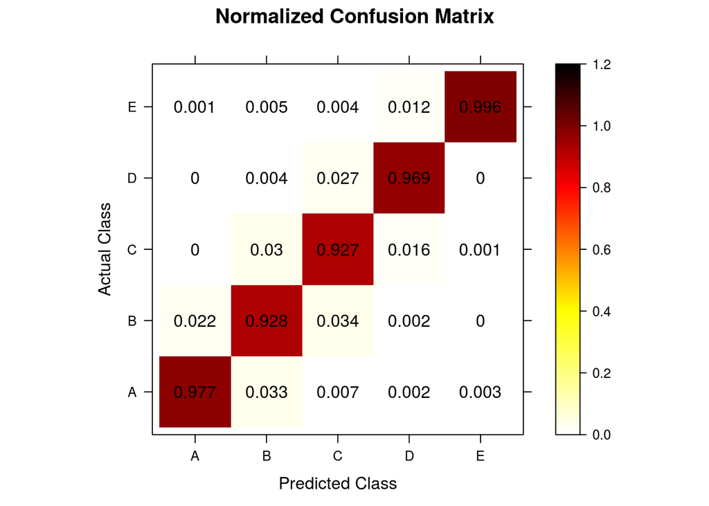

# Prediction

The model is finally applied to the test dataset for evaluation.

```r
pred <- predict(fit1, test)
pred
```

```
##  [1] B A B A A E D B A A B C B A E E A B B B
## Levels: A B C D E
```

# Bibliography

[1] Velloso, E.; Bulling, A.; Gellersen, H.; Ugulino, W.; Fuks, H. Qualitative Activity Recognition of Weight Lifting Exercises. *Proceedings of 4th International Conference in Cooperation with SIGCHI (Augmented Human ’13)* . Stuttgart, Germany: ACM SIGCHI, 2013.